# BANA7038_Final

bollara,taridaar,anchurmu,gangamrh

December 2, 2015

Summary:

The Concrete Compressive strentgh is a dataset consisting all the following attributes: cement, blast furnace slag, fly ash,water, superplasticizer, coarse aggregate, and fine aggregate.

The concrete compressive strength is a highly nonlinear function of age and ingredients. We built a model for calculatig the concrete compressive strength.

Backward elimination is followed to optimise the model to get best concrete compressive strength.

polynomial Regression is seen with Age variable and hence its higher degree can be used to get optimised model.

Min square residuals and MallowCp is calculated and seen along with R-square values to confirm the model valuation.

**Function which returns the Model Evaluators for input model**

```r
ModelEvaluators <- function(RegModel,x,n,p){

# Calculate Predicted-RSquared value

PRESS_res=RegModel$residuals/(1 - lm.influence(RegModel)$hat)
PRESS=sum(PRESS_res^2)
SST = sum((ip_data$ConcreteCompressiveStrength-mean(ip_data$ConcreteCompressiveStrength))^2)
R_square_pred=1-PRESS/SST

# Calcuate SSRes

SSRes=sum((ip_data$ConcreteCompressiveStrength-RegModel$fitted.values)^2)
MSRes = SSRes / (n-p)
#Res_Std_Error = sqrt(deviance(RegModel)/df.residual(RegModel))

# Calcuate F-Statistic

FStatistic = summary(RegModel)$fstatistic[1]

# R-Square

R_square = summary(RegModel)$r.square

# Adjusted R-Squared

Adj_R_squared = summary(RegModel)$adj.r.squared

AIC = extractAIC(RegModel)
BIC = extractAIC(RegModel, k = log(n))

MallowsCp = leaps( x=x, y=ip_data$ConcreteCompressiveStrength, method="Cp")

return(c(R_square,Adj_R_squared,R_square_pred,FStatistic,MSRes,n,p,AIC,BIC,MallowsCp))
}
```

```
## [1] "Cement"                      "BlastFurnaceSlag"
## [3] "FlyAsh"                      "Water"
## [5] "Superplasticizer"            "CoarseAggregate"
## [7] "FineAggregate"               "Age"
## [9] "ConcreteCompressiveStrength"
```

```
##                      Cement            BlastFurnaceSlag
##                   "numeric"                   "numeric"
##                      FlyAsh                       Water
##                   "numeric"                   "numeric"
##            Superplasticizer             CoarseAggregate
##                   "numeric"                   "numeric"
##               FineAggregate                         Age
##                   "numeric"                   "integer"
## ConcreteCompressiveStrength
##                   "numeric"
```

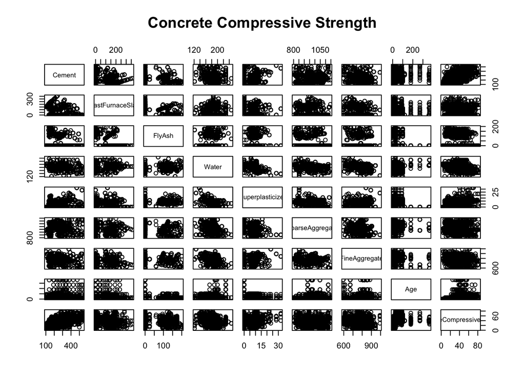

```
##      Cement      BlastFurnaceSlag     FlyAsh           Water
##  Min.   :102.0   Min.   :  0.0    Min.   :  0.00   Min.   :121.8
##  1st Qu.:192.4   1st Qu.:  0.0    1st Qu.:  0.00   1st Qu.:164.9
##  Median :272.9   Median : 22.0    Median :  0.00   Median :185.0
##  Mean   :281.2   Mean   : 73.9    Mean   : 54.19   Mean   :181.6
##  3rd Qu.:350.0   3rd Qu.:142.9    3rd Qu.:118.30   3rd Qu.:192.0
##  Max.   :540.0   Max.   :359.4    Max.   :200.10   Max.   :247.0
##  Superplasticizer CoarseAggregate  FineAggregate        Age
##  Min.   : 0.000   Min.   : 801.0   Min.   :594.0   Min.   :  1.00
##  1st Qu.: 0.000   1st Qu.: 932.0   1st Qu.:731.0   1st Qu.:  7.00
##  Median : 6.400   Median : 968.0   Median :779.5   Median : 28.00
##  Mean   : 6.205   Mean   : 972.9   Mean   :773.6   Mean   : 45.66
##  3rd Qu.:10.200   3rd Qu.:1029.4   3rd Qu.:824.0   3rd Qu.: 56.00
##  Max.   :32.200   Max.   :1145.0   Max.   :992.6   Max.   :365.00
##  ConcreteCompressiveStrength
##  Min.   : 2.33
##  1st Qu.:23.71
##  Median :34.45
##  Mean   :35.82
##  3rd Qu.:46.13
##  Max.   :82.60
```

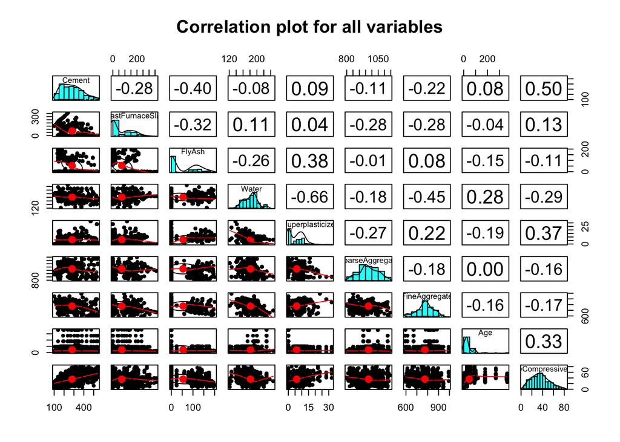

**Model Building with Backward elimination**

```r
n = nrow(ip_data)

x1 = cbind(ip_data$Cement, ip_data$BlastFurnaceSlag, ip_data$FlyAsh, ip_data$Water, ip_data$Superplasticizer, ip_data$CoarseAggregate,ip_data$FineAggregate, ip_data$Age)

model1 <- lm(ConcreteCompressiveStrength ~ Cement + BlastFurnaceSlag + FlyAsh + Water + Superplasticizer + CoarseAggregate + FineAggregate + Age, data=ip_data)
summary(model1)
```

```
##
## Call:
## lm(formula = ConcreteCompressiveStrength ~ Cement + BlastFurnaceSlag +
##     FlyAsh + Water + Superplasticizer + CoarseAggregate + FineAggregate +
##     Age, data = ip_data)
##
## Residuals:
##     Min      1Q  Median      3Q     Max
## -28.654  -6.302   0.703   6.569  34.450
##
## Coefficients:
##                    Estimate Std. Error t value Pr(>|t|)
## (Intercept)      -23.331214  26.585504  -0.878 0.380372
## Cement             0.119804   0.008489  14.113  < 2e-16 ***
## BlastFurnaceSlag   0.103866   0.010136  10.247  < 2e-16 ***
## FlyAsh             0.087934   0.012583   6.988 5.02e-12 ***
## Water             -0.149918   0.040177  -3.731 0.000201 ***
## Superplasticizer   0.292225   0.093424   3.128 0.001810 **
## CoarseAggregate    0.018086   0.009392   1.926 0.054425 .
## FineAggregate      0.020190   0.010702   1.887 0.059491 .
## Age                0.114222   0.005427  21.046  < 2e-16 ***
## ---
## Signif. codes:  0 '***' 0.001 '**' 0.01 '*' 0.05 '.' 0.1 ' ' 1
##
## Residual standard error: 10.4 on 1021 degrees of freedom
## Multiple R-squared:  0.6155, Adjusted R-squared:  0.6125
## F-statistic: 204.3 on 8 and 1021 DF,  p-value: < 2.2e-16
```

```r
M1 = ModelEvaluators(model1,x1,n,9)
```

Since t-value for FineAggregate and CoarseAggregate are very small. We will be removing them to optimize model. F-statistic values seems to be small and R-square values.

```r
model2 <- lm(ConcreteCompressiveStrength ~ Cement + BlastFurnaceSlag + FlyAsh + Water + Superplasticizer + Age, data=ip_data)
x2 = cbind(ip_data$Cement, ip_data$BlastFurnaceSlag, ip_data$FlyAsh, ip_data$Water, ip_data$Superplasticizer, ip_data$Age)
summary(model2)
```

```
##
## Call:
## lm(formula = ConcreteCompressiveStrength ~ Cement + BlastFurnaceSlag +
##     FlyAsh + Water + Superplasticizer + Age, data = ip_data)
##
## Residuals:
##     Min      1Q  Median      3Q     Max
## -28.987  -6.469   0.653   6.547  34.732
##
## Coefficients:
##                   Estimate Std. Error t value Pr(>|t|)
## (Intercept)      28.992982   4.213202   6.881 1.03e-11 ***
## Cement            0.105413   0.004246  24.825  < 2e-16 ***
## BlastFurnaceSlag  0.086472   0.004974  17.385  < 2e-16 ***
## FlyAsh            0.068660   0.007735   8.877  < 2e-16 ***
## Water            -0.218088   0.021129 -10.322  < 2e-16 ***
## Superplasticizer  0.240311   0.084567   2.842  0.00458 **
## Age               0.113492   0.005407  20.988  < 2e-16 ***
## ---
## Signif. codes:  0 '***' 0.001 '**' 0.01 '*' 0.05 '.' 0.1 ' ' 1
##
## Residual standard error: 10.41 on 1023 degrees of freedom
## Multiple R-squared:  0.614,  Adjusted R-squared:  0.6118
## F-statistic: 271.2 on 6 and 1023 DF,  p-value: < 2.2e-16
```

```r
vif(model2)
```

```
##           Cement BlastFurnaceSlag           FlyAsh            Water
##         1.870198         1.748922         2.327145         1.933421
## Superplasticizer              Age
##         2.423758         1.108130
```

```r
M2 = ModelEvaluators(model2,x2,n,7)
```

Since we have seen same R-square value, we can confirm FineAggregate and CoarseAggregate are not contributing much to the model.

From Pairs plot it looks like a polynomial for variable Age with ConcreteCompressiveStrength **Polynomial Test**

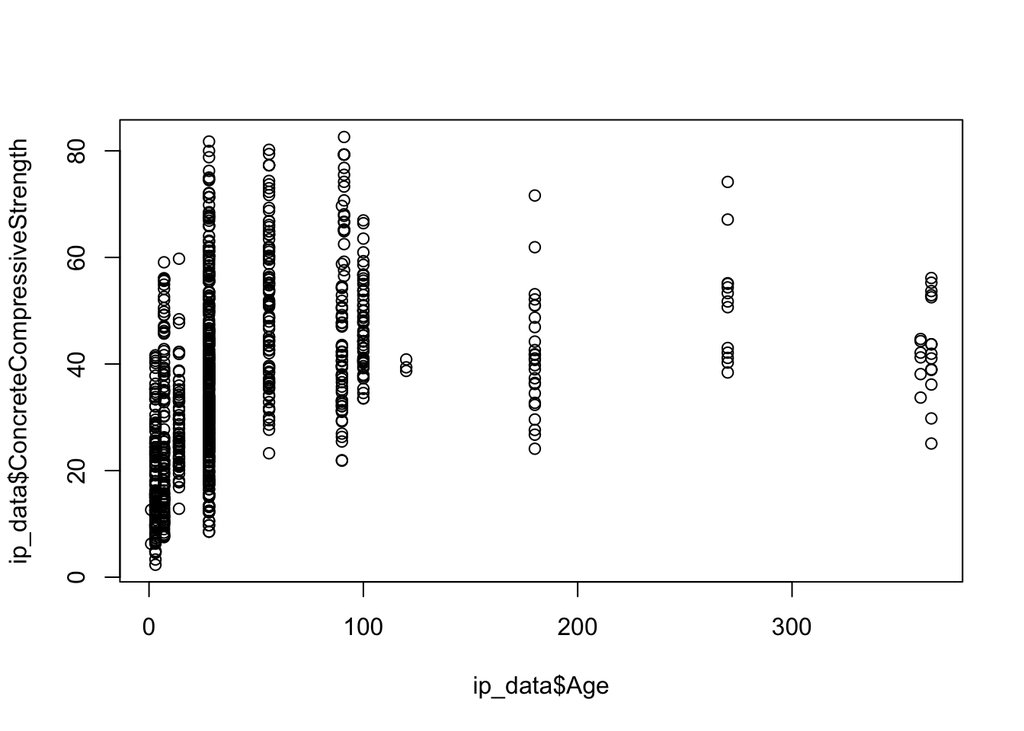

Above graph looks like there exists a polynomial with variable Age.

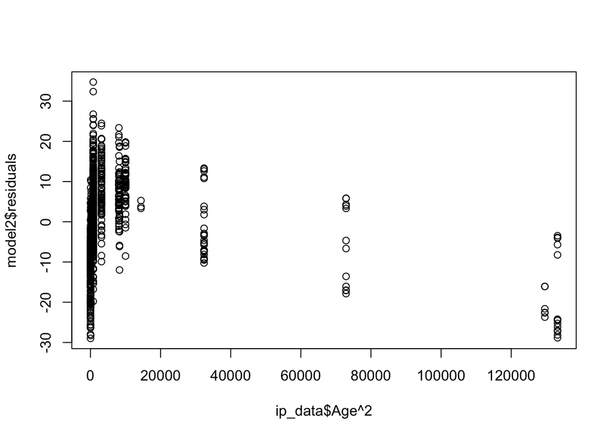

From the above residual plot it can be observed that there is some pattern.Hence, adding age^2 as a regressor variabel might fit the model better.

**Test by Adding Age^2**

```r
model3 <- lm(ConcreteCompressiveStrength ~ Cement + BlastFurnaceSlag + FlyAsh + Water + Superplasticizer + Age+ I(Age^2), data=ip_data)
x3 = cbind(ip_data$Cement, ip_data$BlastFurnaceSlag, ip_data$FlyAsh, ip_data$Water, ip_data$Superplasticizer, ip_data$Age + (ip_data$Age^2))
summary(model3)
```

```
##
## Call:
## lm(formula = ConcreteCompressiveStrength ~ Cement + BlastFurnaceSlag +
##     FlyAsh + Water + Superplasticizer + Age + I(Age^2), data = ip_data)
##
## Residuals:
##     Min      1Q  Median      3Q     Max
## -23.791  -5.045   0.007   4.926  34.767
##
## Coefficients:
##                    Estimate Std. Error t value Pr(>|t|)
## (Intercept)       2.104e+01  3.457e+00   6.087 1.62e-09 ***
## Cement            1.066e-01  3.466e-03  30.750  < 2e-16 ***
## BlastFurnaceSlag  8.716e-02  4.060e-03  21.468  < 2e-16 ***
## FlyAsh            6.458e-02  6.316e-03  10.225  < 2e-16 ***
## Water            -2.061e-01  1.726e-02 -11.944  < 2e-16 ***
## Superplasticizer  1.790e-01  6.908e-02   2.592  0.00969 **
## Age               3.532e-01  1.146e-02  30.812  < 2e-16 ***
## I(Age^2)         -8.160e-04  3.601e-05 -22.659  < 2e-16 ***
## ---
## Signif. codes:  0 '***' 0.001 '**' 0.01 '*' 0.05 '.' 0.1 ' ' 1
##
## Residual standard error: 8.497 on 1022 degrees of freedom
## Multiple R-squared:  0.7431, Adjusted R-squared:  0.7413
## F-statistic: 422.3 on 7 and 1022 DF,  p-value: < 2.2e-16
```

```r
vif(model3)
```

```
##           Cement BlastFurnaceSlag           FlyAsh            Water
##         1.870621         1.749020         2.329037         1.935240
## Superplasticizer              Age         I(Age^2)
##         2.427479         7.473744         7.539717
```

```r
M3 = ModelEvaluators(model3,x3,n,8)
```

**Test by Adding Age^3**

```r
model4 <- lm(ConcreteCompressiveStrength ~ Cement + BlastFurnaceSlag + FlyAsh + Water + Superplasticizer + Age+ I(Age^2) + I(Age^3), data=ip_data)
x4 = cbind(ip_data$Cement, ip_data$BlastFurnaceSlag, ip_data$FlyAsh, ip_data$Water, ip_data$Superplasticizer, ip_data$Age + (ip_data$Age^2) + (ip_data$Age^3))
summary(model4)
```

```
##
## Call:
## lm(formula = ConcreteCompressiveStrength ~ Cement + BlastFurnaceSlag +
##     FlyAsh + Water + Superplasticizer + Age + I(Age^2) + I(Age^3),
##     data = ip_data)
##
## Residuals:
##     Min      1Q  Median      3Q     Max
## -20.964  -4.684  -0.331   4.079  33.231
##
## Coefficients:
##                    Estimate Std. Error t value Pr(>|t|)
## (Intercept)       1.402e+01  3.105e+00   4.514 7.11e-06 ***
## Cement            1.109e-01  3.095e-03  35.833  < 2e-16 ***
## BlastFurnaceSlag  8.588e-02  3.613e-03  23.769  < 2e-16 ***
## FlyAsh            6.051e-02  5.625e-03  10.757  < 2e-16 ***
## Water            -1.938e-01  1.537e-02 -12.608  < 2e-16 ***
## Superplasticizer  8.295e-02  6.174e-02   1.344    0.179
## Age               6.542e-01  2.097e-02  31.202  < 2e-16 ***
## I(Age^2)         -3.892e-03  1.899e-04 -20.492  < 2e-16 ***
## I(Age^3)          6.439e-06  3.918e-07  16.432  < 2e-16 ***
## ---
## Signif. codes:  0 '***' 0.001 '**' 0.01 '*' 0.05 '.' 0.1 ' ' 1
##
## Residual standard error: 7.56 on 1021 degrees of freedom
## Multiple R-squared:  0.7968, Adjusted R-squared:  0.7952
## F-statistic: 500.5 on 8 and 1021 DF,  p-value: < 2.2e-16
```

```r
vif(model4)
```

```
##           Cement BlastFurnaceSlag           FlyAsh            Water
##         1.884238         1.749833         2.333564         1.939849
## Superplasticizer              Age         I(Age^2)         I(Age^3)
##         2.449447        31.588909       264.943640       134.293147
```

```r
M4 = ModelEvaluators(model4,x4,n,9)
```

```r
ip_data$Age_centered <- ip_data$Age-mean(ip_data$Age)
model5 <- lm(ConcreteCompressiveStrength ~ Cement + BlastFurnaceSlag + FlyAsh + Water + Superplasticizer + Age_centered + I(Age_centered^2), data=ip_data)
x5 = cbind(ip_data$Cement, ip_data$BlastFurnaceSlag, ip_data$FlyAsh, ip_data$Water, ip_data$Superplasticizer, ip_data$Age_centered, I(ip_data$Age_centered^2))
summary(model5)
```

```
##
## Call:
## lm(formula = ConcreteCompressiveStrength ~ Cement + BlastFurnaceSlag +
##     FlyAsh + Water + Superplasticizer + Age_centered + I(Age_centered^2),
##     data = ip_data)
##
## Residuals:
##     Min      1Q  Median      3Q     Max
## -23.791  -5.045   0.007   4.926  34.767
##
## Coefficients:
##                     Estimate Std. Error t value Pr(>|t|)
## (Intercept)        3.547e+01  3.472e+00  10.215  < 2e-16 ***
## Cement             1.066e-01  3.466e-03  30.750  < 2e-16 ***
## BlastFurnaceSlag   8.716e-02  4.060e-03  21.468  < 2e-16 ***
## FlyAsh             6.458e-02  6.316e-03  10.225  < 2e-16 ***
## Water             -2.061e-01  1.726e-02 -11.944  < 2e-16 ***
## Superplasticizer   1.790e-01  6.908e-02   2.592  0.00969 **
## Age_centered       2.787e-01  8.522e-03  32.700  < 2e-16 ***
## I(Age_centered^2) -8.160e-04  3.601e-05 -22.659  < 2e-16 ***
## ---
## Signif. codes:  0 '***' 0.001 '**' 0.01 '*' 0.05 '.' 0.1 ' ' 1
##
## Residual standard error: 8.497 on 1022 degrees of freedom
## Multiple R-squared:  0.7431, Adjusted R-squared:  0.7413
## F-statistic: 422.3 on 7 and 1022 DF,  p-value: < 2.2e-16
```

```r
vif(model5)
```

```
##            Cement  BlastFurnaceSlag            FlyAsh             Water
##          1.870621          1.749020          2.329037          1.935240
##  Superplasticizer      Age_centered I(Age_centered^2)
##          2.427479          4.131094          4.147565
```

```r
M5 = ModelEvaluators(model5,x5,n,8)

ConcreteModel <- model5
```

**MODEL EVALUATION**

| Model # | Co-variates List | Multiple R_Squared | Adjusted R_Squared | Predicted R_Squared | F-Statistic | MSRes | n | p | AIC | BIC | MallowsCp |
| --- | --- | --- | --- | --- | --- | --- | --- | --- | --- | --- | --- |
| 1 | All Co-variates | 0.6155199 | 0.6125073 | 0.6068634 | 204.3167317 | 108.1421676 | 1030 | 9 | 9 | 4832.9105794 | 9 |
| 2 | Remove Two Variables | 0.6140224 | 0.6117586 | 0.6069759 | 271.2354308 | 108.3511257 | 1030 | 7 | 7 | 4832.9145362 | 7 |
| 3 | Add Age^2 | 0.7430862 | 0.7413266 | 0.7379402 | 422.2840848 | 72.1910534 | 1030 | 8 | 8 | 4415.6643786 | 8 |
| 4 | Add Age^3 | 0.796817 | 0.795225 | 0.7918675 | 500.5034625 | 57.1489759 | 1030 | 9 | 9 | 4175.9917644 | 9 |
| 5 | **Shift Age’s Centers** | **0.7430862** | **0.7413266** | **0.7379402** | **422.2840848** | **72.1910534** | **1030** | **8** | **8** | **4415.6643786** | **8** |

From analysing the above table, following observations helped us in choosing the highlighted model

1. A high value for R_squared, Adj_ R_Squared and Pred_R_squared is desired.
2. AIC value, near to number of parameters+1 is desired, it helps us in estimating the quality of each model. Its value gives us an estimate of trade-off between goodness of fit of the model and model complexity.
3. Small value for BIC is preferred. It gives similar value as AIC, but the penality term is larger in BIC.
4. Adding Ageˆ3 as a regressor variable increases R^2 value but the VIF values are very high and is not desired.Hence model4 is not considered. 5)Low values for MSRes is desired.

** Test by BOXcox method**

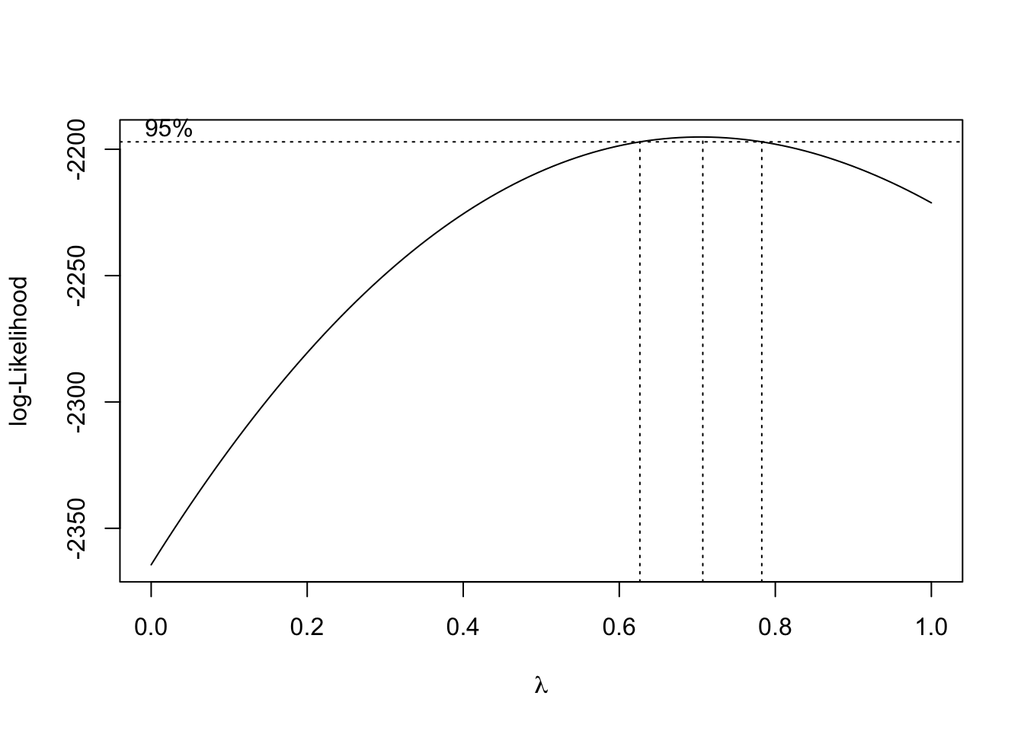

```r
require(MASS)

boxcox(model3,seq(0, 1, 0.1))
```

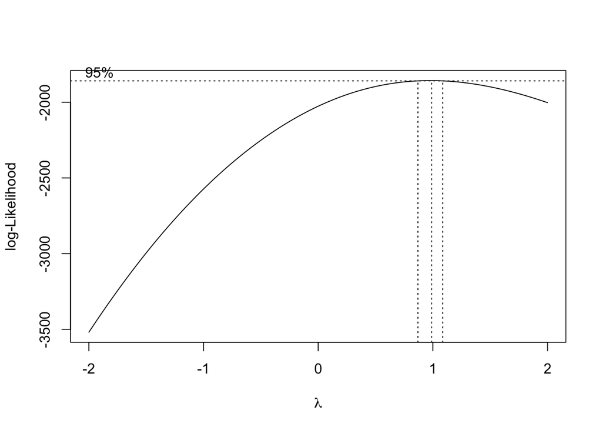

```r
ip_data <- cbind(ip_data, ip_data$ConcreteCompressiveStrength^0.72)
names(ip_data)[11] <- "Yprime"
BoxcoxModel<-lm(Yprime~Cement+BlastFurnaceSlag+FlyAsh+Water+Superplasticizer+Age_centered+I(Age_centered^2),data=ip_data)
boxcox(BoxcoxModel)
```

```r
vif(BoxcoxModel)
```

```
##            Cement  BlastFurnaceSlag            FlyAsh             Water
##          1.870621          1.749020          2.329037          1.935240
##  Superplasticizer      Age_centered I(Age_centered^2)
##          2.427479          4.131094          4.147565
```

```r
M5 = ModelEvaluators(BoxcoxModel,x3,n,9)

summary(BoxcoxModel)
```

```
##
## Call:
## lm(formula = Yprime ~ Cement + BlastFurnaceSlag + FlyAsh + Water +
##     Superplasticizer + Age_centered + I(Age_centered^2), data = ip_data)
##
## Residuals:
##    Min     1Q Median     3Q    Max
## -6.863 -1.371  0.070  1.485  8.184
##
## Coefficients:
##                     Estimate Std. Error t value Pr(>|t|)
## (Intercept)        1.210e+01  9.284e-01  13.037  < 2e-16 ***
## Cement             2.862e-02  9.268e-04  30.884  < 2e-16 ***
## BlastFurnaceSlag   2.318e-02  1.086e-03  21.354  < 2e-16 ***
## FlyAsh             1.847e-02  1.689e-03  10.939  < 2e-16 ***
## Water             -5.199e-02  4.613e-03 -11.269  < 2e-16 ***
## Superplasticizer   4.826e-02  1.847e-02   2.613  0.00911 **
## Age_centered       7.556e-02  2.279e-03  33.162  < 2e-16 ***
## I(Age_centered^2) -2.208e-04  9.628e-06 -22.930  < 2e-16 ***
## ---
## Signif. codes:  0 '***' 0.001 '**' 0.01 '*' 0.05 '.' 0.1 ' ' 1
##
## Residual standard error: 2.272 on 1022 degrees of freedom
## Multiple R-squared:  0.7428, Adjusted R-squared:  0.7411
## F-statistic: 421.7 on 7 and 1022 DF,  p-value: < 2.2e-16
```

We didn’t see much optimised value with this Boxcox Model.

**Residual Plots**

**Residual Plots against Regressors not in the Model**

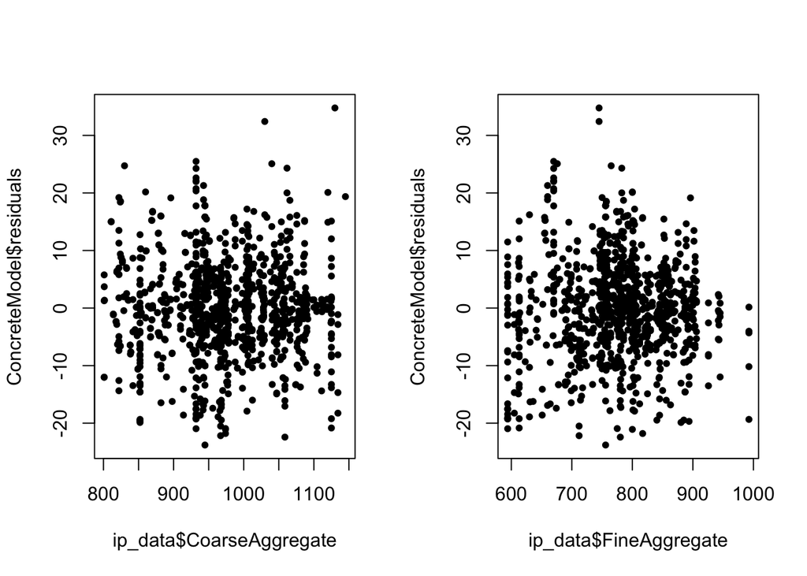

There is no concrete pattern, therefore the regressor variables not in the model, aren’t significant enough to be added in the model. The model is fine.

**Residual Plots against Regressors in the Model**

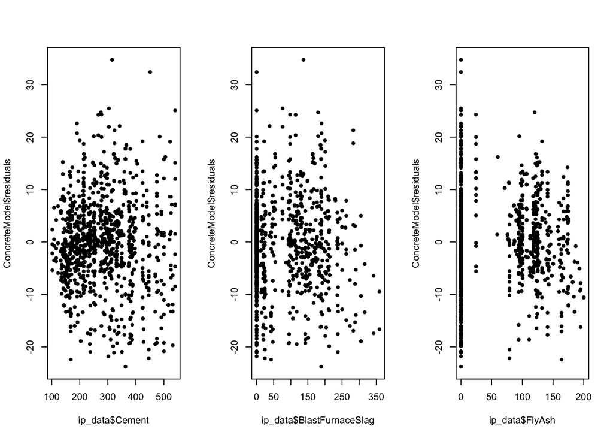

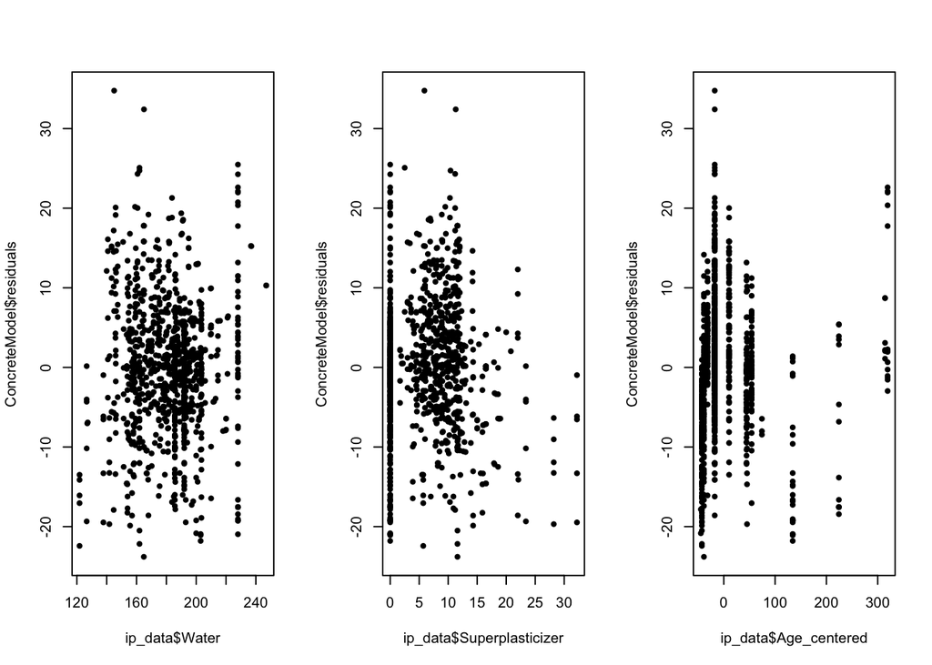

There is no definite pattern, therefore the regressor variables of the model, explained the variation in data well.

[figure not shown]

```
##        Length Class  Mode
## coef   168    -none- numeric
## scales   8    -none- numeric
## Inter    1    -none- numeric
## lambda  21    -none- numeric
## ym       1    -none- numeric
## xm       8    -none- numeric
## GCV     21    -none- numeric
## kHKB     1    -none- numeric
## kLW      1    -none- numeric
```

```
## modified HKB estimator is 0.09561057
## modified L-W estimator is 1.543446
## smallest value of GCV  at 0
```

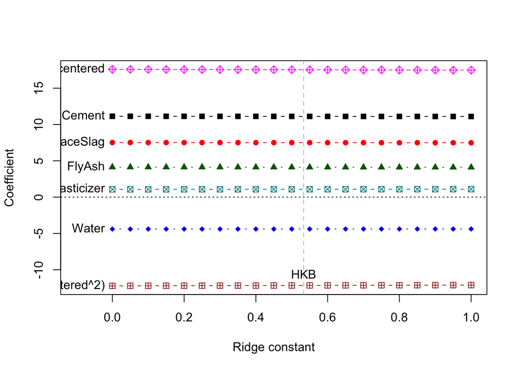

Ridge regression didnt help much for stablising vif value. Hence this model is not considered.

**Coefficient Estimates and their Confidence Intervals obtained from Model**

[output not shown]

The 95% Confidence Intervals of Coefficient Estimates given above, is the Average/Estimated value of the Coefficients. So, with 95% confidence we say that the values of these estimates fall within the interval specified for any sample chosen. And only 5% value of the estimates, may fall outside the confidence interval.

[output not shown]

Total Sums of Squares, SST is the Total Variation in the data. SST, value is fixed, irrespective of the model. SST = SSR + SSRes.

Since we have a very low value of SSRes when compared to SSR here, the variation in response variable/data that can be explained by the model is more than the variation that cannot be explained. It is desired to have low value for SSRes and high value for SSR. Hence, this model evolve as the best fit for the data.

**ANOVA Results for the Model & F-Test**

```
## Analysis of Variance Table
##
## Response: ConcreteCompressiveStrength
##                     Df Sum Sq Mean Sq F value    Pr(>F)
## Cement               1  71173   71173 985.891 < 2.2e-16 ***
## BlastFurnaceSlag     1  22961   22961 318.053 < 2.2e-16 ***
## FlyAsh               1  21639   21639 299.741 < 2.2e-16 ***
## Water                1  11458   11458 158.713 < 2.2e-16 ***
## Superplasticizer     1   1374    1374  19.039 1.411e-05 ***
## Age_centered         1  47728   47728 661.137 < 2.2e-16 ***
## I(Age_centered^2)    1  37064   37064 513.415 < 2.2e-16 ***
## Residuals         1022  73779      72
## ---
## Signif. codes:  0 '***' 0.001 '**' 0.01 '*' 0.05 '.' 0.1 ' ' 1
```

**Inference**

**Compute 95% Confidence Intervals for Fitted Values(Mean Responses)**

```r
ConfValues = predict(ConcreteModel,ip_data,level=.95,interval="confidence",type="response")
```

The final Polynomial Regression model is:  
ConcreteCompressiveStrength ~ Cement + BlastFurnaceSlag + FlyAsh + Water + Superplasticizer + Age_centered + I(Age_centered^2)